# GLM I - Ordinary Linear Regression

## Setting the stage

## Dataset

We will use the [`palmerpenguins`](https://allisonhorst.github.io/palmerpenguins/) dataset to demonstrate.

## Let’s explore

```r
summary(penguins)
```

|  | species | island | bill_length_mm | bill_depth_mm | flipper_length_mm | body_mass_g | sex | year |
| --- | --- | --- | --- | --- | --- | --- | --- | --- |
|  | Adelie :152 | Biscoe :168 | Min. :32.10 | Min. :13.10 | Min. :172.0 | Min. :2700 | female:165 | Min. :2007 |
|  | Chinstrap: 68 | Dream :124 | 1st Qu.:39.23 | 1st Qu.:15.60 | 1st Qu.:190.0 | 1st Qu.:3550 | male :168 | 1st Qu.:2007 |
|  | Gentoo :124 | Torgersen: 52 | Median :44.45 | Median :17.30 | Median :197.0 | Median :4050 | NA’s : 11 | Median :2008 |
|  | NA | NA | Mean :43.92 | Mean :17.15 | Mean :200.9 | Mean :4202 | NA | Mean :2008 |
|  | NA | NA | 3rd Qu.:48.50 | 3rd Qu.:18.70 | 3rd Qu.:213.0 | 3rd Qu.:4750 | NA | 3rd Qu.:2009 |
|  | NA | NA | Max. :59.60 | Max. :21.50 | Max. :231.0 | Max. :6300 | NA | Max. :2009 |
|  | NA | NA | NA’s :2 | NA’s :2 | NA’s :2 | NA’s :2 | NA | NA |

```r
peng <- penguins[complete.cases(penguins), ]
```

## Define a relationship

\[ \begin{aligned} Y &= f(X) \\ Y &= \beta_0 + \beta_1X \\ \end{aligned} \] \[ \begin{aligned} \beta_0 &= 137, \beta_1 = .015 \\ Y &= 137 + .015X \end{aligned} \]

## Define a relationship - Plot

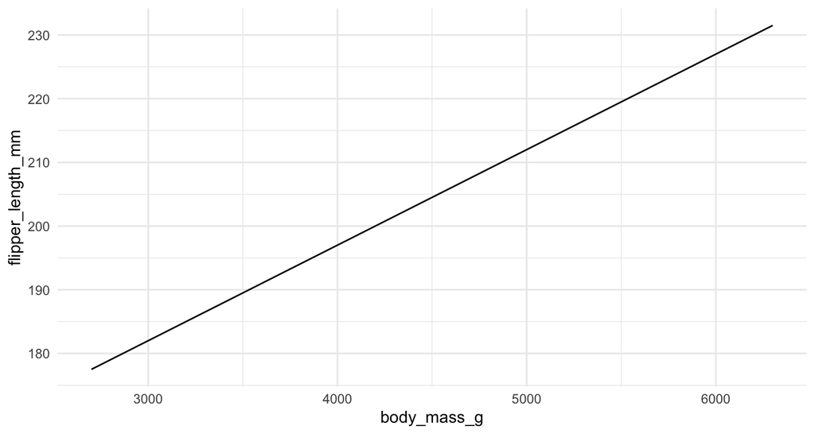

```r
sim_data <- data.frame(
  body_mass_g = seq(from = 2700, to = 6300, length.out = 400)
)
sim_data$flipper_length_mm <- 137 + sim_data$body_mass_g * .015
ggplot(sim_data, aes(x = body_mass_g, y = flipper_length_mm)) +
  geom_line()
```

## Interpertation

\[ \begin{aligned} \beta_0 &= 137, \beta_1 = .015 \\ Y &= 137 + .015X \end{aligned} \]

- What does \(\beta_0\) and \(\beta_1\) represent?
- What are we missing?

## Overlay the actual data

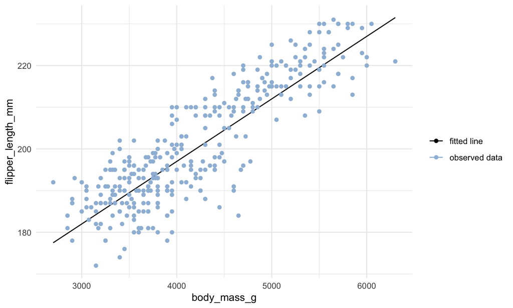

## How do we model the data generating process?

- How can we better mimic the data that we see?
- We can add random noise
- What kind of random noise can we add?
- What can we say about the random noise?

## Random Variables - an aside

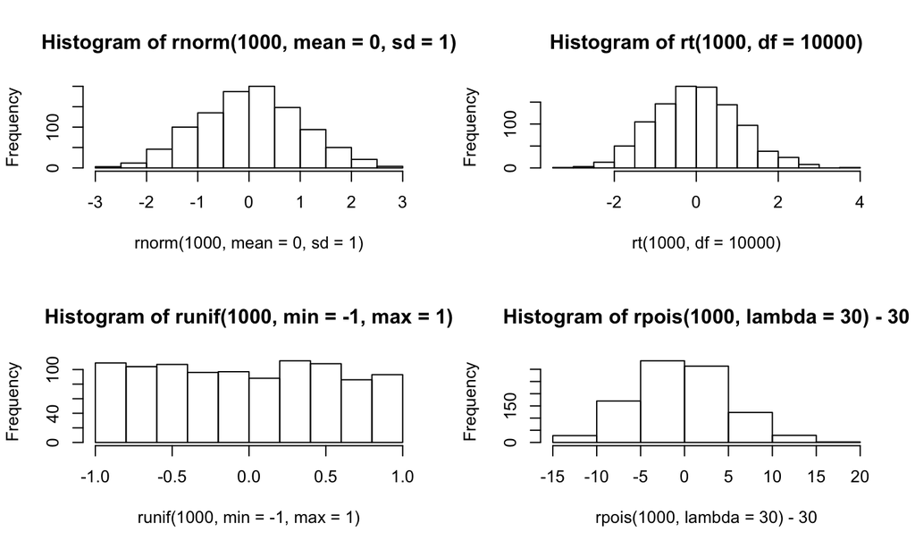

## Random Variables

### learn more

```r
?distribution
```

| Distributions | R Documentation |
| --- | --- |

## Distributions in the stats package

### Description

Density, cumulative distribution function, quantile function and random variate generation for many standard probability distributions are available in the stats package.

### Details

The functions for the density/mass function, cumulative distribution function, quantile function and random variate generation are named in the form `dxxx`, `pxxx`, `qxxx` and `rxxx` respectively.

For the beta distribution see `dbeta`.

For the binomial (including Bernoulli) distribution see `dbinom`.

For the Cauchy distribution see `dcauchy`.

For the chi-squared distribution see `dchisq`.

For the exponential distribution see `dexp`.

For the F distribution see `df`.

For the gamma distribution see `dgamma`.

For the geometric distribution see `dgeom`. (This is also a special case of the negative binomial.)

For the hypergeometric distribution see `dhyper`.

For the log-normal distribution see `dlnorm`.

For the multinomial distribution see `dmultinom`.

For the negative binomial distribution see `dnbinom`.

For the normal distribution see `dnorm`.

For the Poisson distribution see `dpois`.

For the Student’s t distribution see `dt`.

For the uniform distribution see `dunif`.

For the Weibull distribution see `dweibull`.

For less common distributions of test statistics see `pbirthday`, `dsignrank`, `ptukey` and `dwilcox` (and see the ‘See Also’ section of `cor.test`).

### See Also

`RNG` about random number generation in **R**.

The CRAN task view on distributions, https://CRAN.R-project.org/view=Distributions, mentioning several CRAN packages for additional distributions.

## Add in random noise

```r
sim_data$flipper_length_mm_w_noise <-
  sim_data$flipper_length_mm + rnorm(nrow(sim_data), mean = 0, sd = 6.8)
```

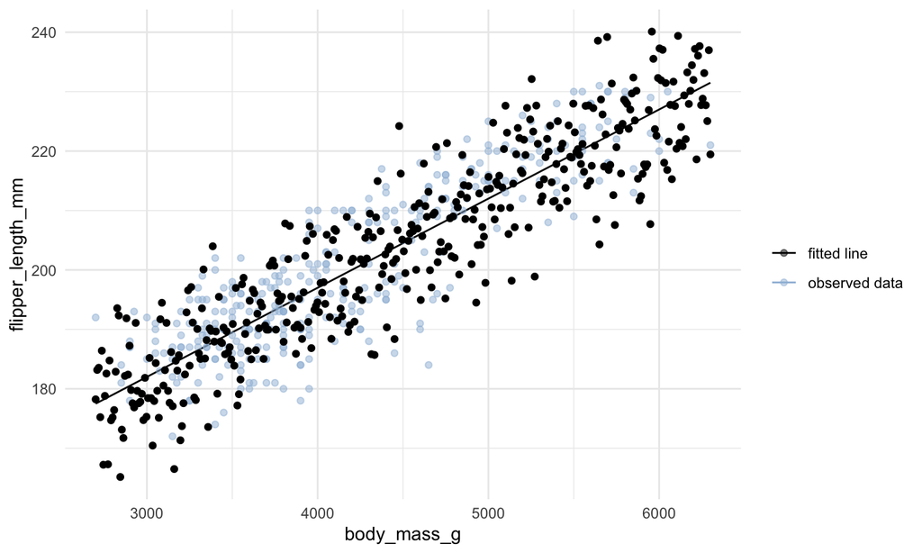

## Formal Statement of Model

\[ Y_i = \beta_0 = \beta_1X_i + \epsilon_i \]

- \(Y_i\) is the value of the response variable in the \(i\)th observation
- \(\beta\)s are the parameters
- \(X_i\) is a known constant
- \(\epsilon_i\) is a random error term with \(E\{\epsilon_i\} = 0\), \(Var\{\epsilon_i\} = \sigma^2\) and \(\sigma\{\epsilon_i, \epsilon_j\} = 0\) for all \(i, j; i \neq j\)

## Features of Model

- Since \(E\{\epsilon_i\} = 0\) we can show that \(E\{Y_i\} = \beta_0 + \beta_1X_i\)
- Similarly \(\sigma^2\{Y_i\} = \sigma^2\)
- Because error terms are uncorrelated - Y’s are uncorrelated

## Interpertation and Alternative Form

- Recall what \(\beta_0\) generally represents in this example
- We can rewrite so that:

\[ Y_i = \beta_0^* + \beta_1(X_i - \bar{X}) + \epsilon_i \]

```r
summary(peng$body_mass_g)
```

| Min. | 1st Qu. | Median | Mean | 3rd Qu. | Max. |
| --- | --- | --- | --- | --- | --- |
| 2700 | 3550 | 4050 | 4207.057 | 4775 | 6300 |

## Estimating the parameters

## How do we know which line is better?

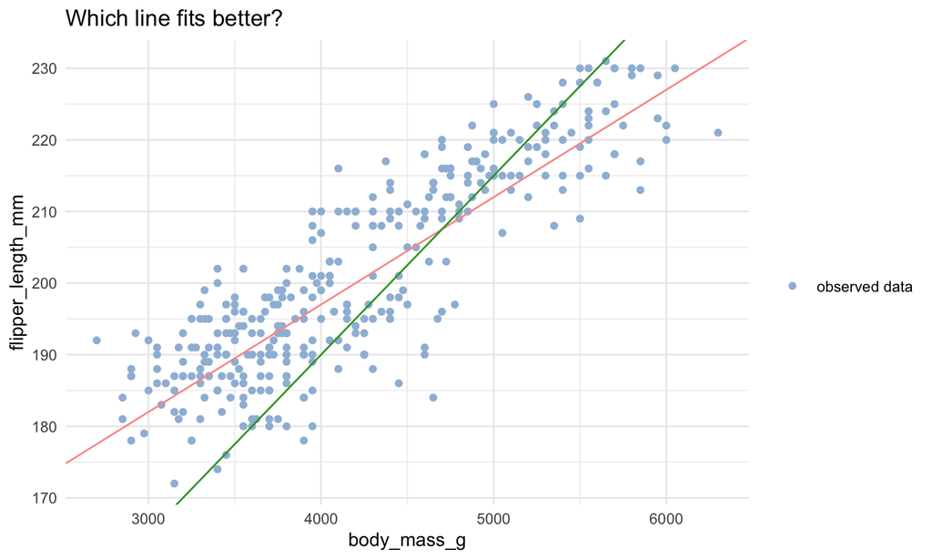

## Method of Least Squares

- We want to minimize \(Q\) where:

\[ Q = \sum^n_{i=1}{(Y_i - \beta_0 - \beta_1X_i)^2} \] our estimates for \(\beta_0\) and \(\beta_1\) will be \(\hat\beta_0\) and \(\hat\beta_1\), respectively.

## Method of Least Squares: Visual

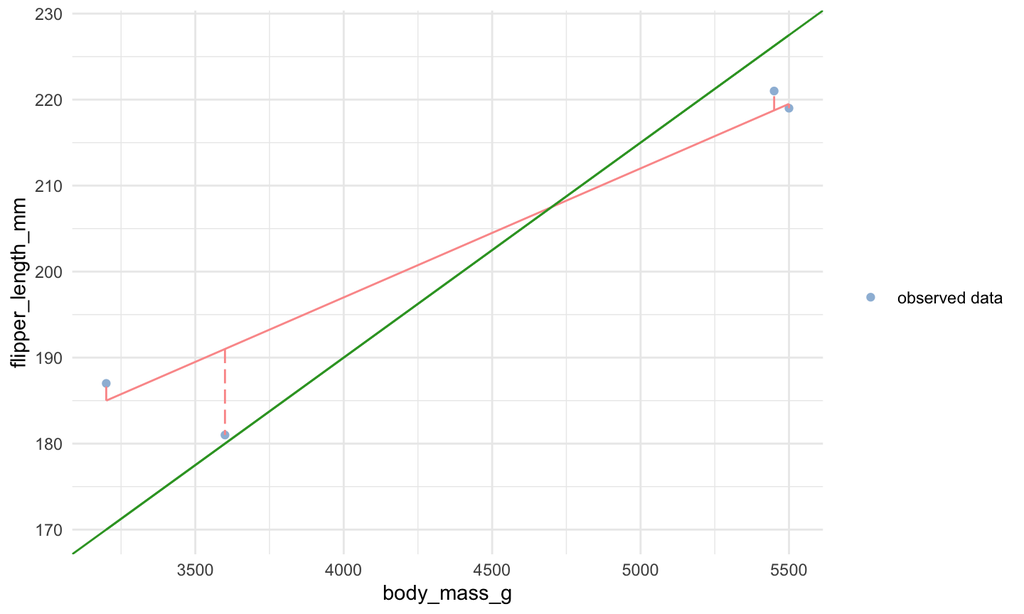

## Calculate *Q*

### Definitions

- Line1: \(Y = 137 + .015X\)
- Line2: \(Y = 90 + .025X\)

| body_mass_g | flipper_length_mm | line1 | line2 |
| --- | --- | --- | --- |
| 3200 | 187 | 185.00 | 170.00 |
| 3600 | 181 | 191.00 | 180.00 |
| 5500 | 219 | 219.50 | 227.50 |
| 5450 | 221 | 218.75 | 226.25 |

## Calculate *Q*

### Definitions

```r
with(d_least_squares, sum((line1 - flipper_length_mm)^2))
```

```
## [1] 109.3125
```

```r
with(d_least_squares, sum((line2 - flipper_length_mm)^2))
```

```
## [1] 389.8125
```

## How do you solve for best \(\hat\beta_0\) and \(\hat\beta_1\)?

### Numerical Search

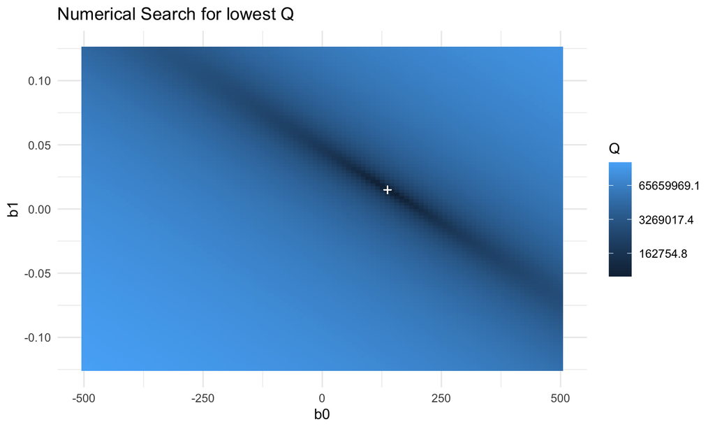

## What are problems with this approach?

- Too slow with lots of parameters (although there are plenty of functions that optimize more efficiently like `optim`).
- If we are looking there is a better way

## How do you solve for best \(\hat\beta_0\) and \(\hat\beta_1\)?

### Analytic Approach

\[ \hat\beta_1 = \frac{\sum{(X_i - \bar{X})(Y_i - \bar{Y})}}{\sum{(X_i - \bar{X})^2}} \]

\[ \hat\beta_0 = ??? \] - \(\hat\beta_0 = \bar{Y} - \hat\beta_1\bar{X}\) - What happens to that equation when we center \(X\)?

- See this [link for a proof](https://are.berkeley.edu/courses/EEP118/current/derive_ols.pdf)
- What happens if we get more data points?

## Solve for \(\hat{\beta_1}\) and \(\hat{\beta_0}\)

```r
x_bar <- mean(peng$body_mass_g)
y_bar <- mean(peng$flipper_length_mm)

beta_1 <- sum((peng$body_mass_g - x_bar)*(peng$flipper_length_mm - y_bar))/sum((peng$body_mass_g - x_bar)^2)
beta_0 <- y_bar - beta_1*x_bar

beta_0
```

```
## [1] 137.0396
```

```r
beta_1
```

```
## [1] 0.01519526
```

## Point Estimation

- If I have a penguin that is 3K, how long do I expect that penguin’s flipper to be?

```
## [1] 182.6254
```

## Residuals

- \(e_i = Y_i - \hat{Y_i} = Y_i - (\hat\beta_0 + \hat\beta_1X_i)\)
- What is this related to?

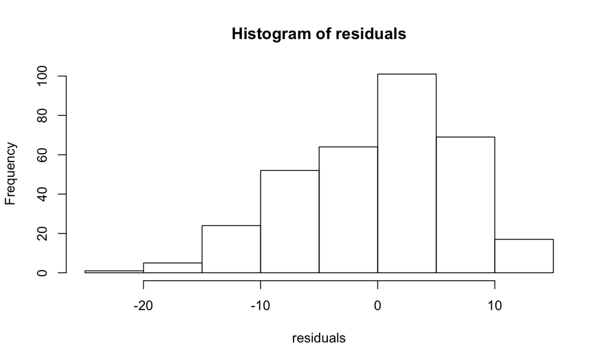

## Properties

- \(\sum^{n}_{i = 1} {e_i} = ?\)
  - \(\sum^{n}_{i = 1} {e_i} = 0\)
- \(\sum^{n}_{i = 1} {e_i^2} = ?\)
  - It’s a minimum (it’s the same as Q)
- \(\sum{Y_i} = \sum{\hat{Y}}\)
- \(\sum{X_ie_i} = 0\)
- \(\sum{\hat{Y_i}e_i} = 0\)
- The regression line will always go through \((\bar{X}, \bar{Y})\)

## Estimation of \(\sigma^2\)

### Sample Variance

- The true variance is \(\sigma^2\), estimate it with \(\hat{\sigma}^2\)

\[ \hat{\sigma}^2 = \frac{\sum^n_{i=1}{(Y_i - \bar{Y})^2}}{n - 1} \]

- Why \(n-1\)?

## Estimation of \(\sigma^2\)

### An Aside (1)

```r
calc_sds <- function(n, true_mean = 0, true_sd = 1){
  x <- rnorm(n, mean = true_mean, sd = true_sd)
  x_bar <- mean(x)

  list(
    true_mean = true_mean,
    true_sd = true_sd,
    s_wrong =  sum((x - x_bar)^2)/n,
    s_cheat = sum((x - true_mean)^2)/n,
    s_standard = sum((x - x_bar)^2)/(n - 1)
  )
}
```

## Estimation of \(\sigma^2\)

### An Aside (2)

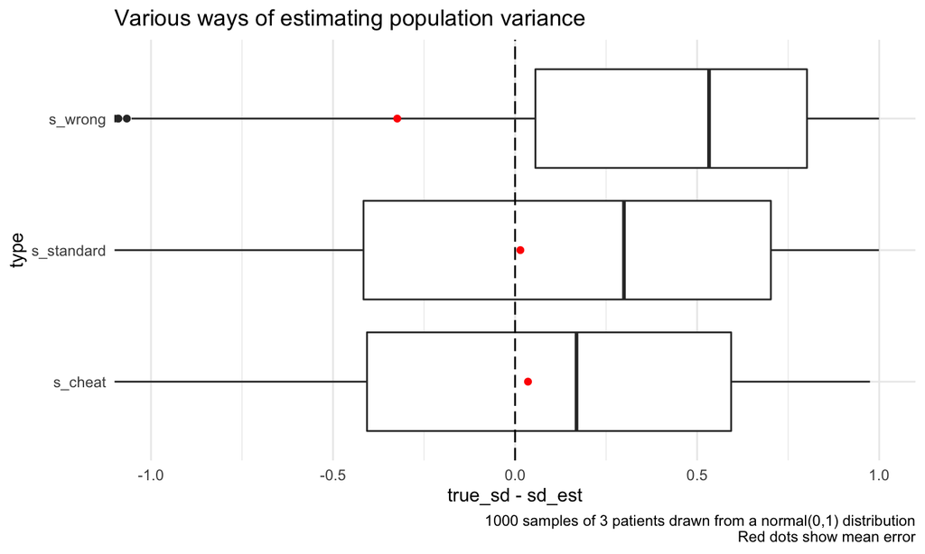

## Estimation of \(\sigma^2\)

### An Aside (3)

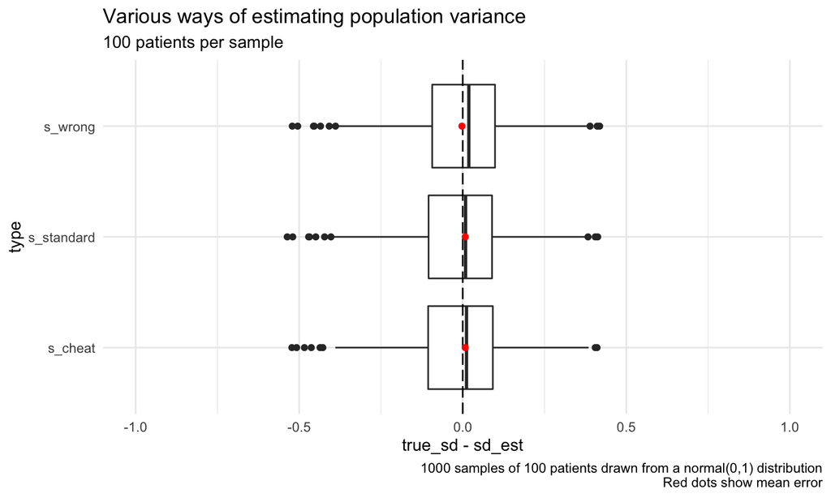

## Estimation of \(\sigma^2\)

- Error sum of squares \[ SSE = \sum^n_{i = 1}(Y_i - \hat{Y_i})^2 \\ \]
- Error mean square

\[ \hat{\sigma}^2 = MSE = \frac{SSE}{n-2} \]

\[ E\{MSE\} = \sigma^2 \]

## Estimation of \(\sigma^2\)

```r
sse <- sum(residuals^2)
mse <- sse/(length(residuals)-2)
mse
```

```
## [1] 46.87621
```

```r
sqrt(mse)
```

```
## [1] 6.84662
```

## Maximum Liklihood Estimation

## Motivation

- No matter what may be the form of the distribution of the error terms the least squares method provides unbiased point estimators of \(\beta_0\) and \(\beta_1\), that have minimum variance among all unbiased linear estimators. To set up interval estimates and make tests, however, we need to make an assumption about the form of the distribution of the error terms.

## Set Up

- How to define the mean/standard deviation

```r
X <- c(250, 265, 259)
```

- Is it more likely to come from `normal(230, 10)` or `normal(260, 5)`

## Set Up

### Visualization

```r
op_1_sample <- rnorm(10000, 230, 10)
op_2_sample <- rnorm(10000, 260, 5)
```

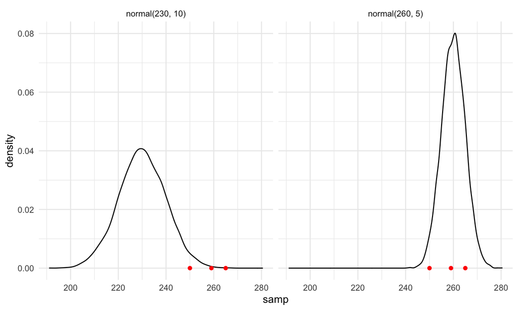

## Sampling vs Density Function

\[ L(\mu, \sigma | x) = \frac{1}{\sqrt{2\pi}\sigma}e^{-\frac{(x-\mu)^2}{2\sigma^2}} \]

```r
raw_norm_eq <- function(x, mu, sigma){
  1/sqrt(2*pi*sigma^2) * exp(-((x-mu)^2/(2*sigma^2)))
}

all.equal(raw_norm_eq(210:260, mu = 230, sigma = 10),
          dnorm(210:260, mean = 230, 10))
```

```
## [1] TRUE
```

## Liklihood Calculation

```r
lh <- data.frame(X = X,
           opt_1_l = dnorm(X, mean = 230, 10),
           opt_2_l = dnorm(X, mean = 260, sd = 5))
```

```r
prod(lh$opt_1_l)
```

```
## [1] 2.804654e-10
```

```r
prod(lh$opt_2_l)
```

```
## [1] 4.086938e-05
```

## LogLiklihood Calculation

- Multiplying ever smaller numbers becomes a problem for the computer so we often work with the logliklihood

```r
sum(log(lh$opt_1_l))
```

```
## [1] -21.99457
```

```r
sum(log(lh$opt_2_l))
```

```
## [1] -10.10513
```

## Finding Optimal Points

- keep sigma constant at 10
- vary the mean

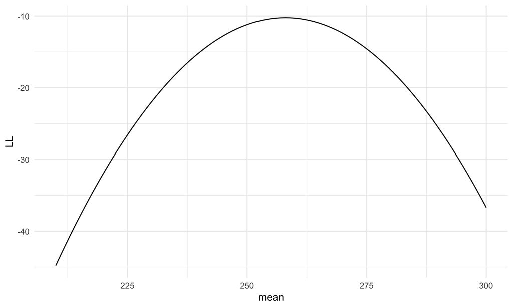

- what can we see about the graph if it is ‘pointier’?
- How can we quantify pointiness?

## Application to regression

\[ \begin{aligned} L(\mu, \sigma | x) & = \frac{1}{\sqrt{2\pi}\sigma}e^{-\frac{(x-\mu)^2}{2\sigma^2}} \\ \mu & = \beta_0 + \beta_1X_i, x = Y_i \\ L(\beta_0, \beta_1, \sigma | X, Y) & = \frac{1}{\sqrt{2\pi}\sigma}e^{-\frac{(Y_i - \beta_0 - \beta_1X_i)^2}{2\sigma^2}} \end{aligned} \]

For *n* points:

\[ \begin{aligned} L(\beta_0, \beta_1, \sigma) & = \prod^{n}_{i=1}\frac{1}{\sqrt{2\pi}\sigma}e^{-\frac{(Y_i - \beta_0 - \beta_1X_i)^2}{2\sigma^2}} \\ \end{aligned} \]

## Solving the parameters

- \(\beta_0\) and \(\beta_1\) are estimated the same as with least squares

\[ \hat{\sigma}^2 = \frac{\sum{(Y_i - \hat{Y_i})^2}}{n} \]

| Min. | 1st Qu. | Median | Mean | 3rd Qu. | Max. |
| --- | --- | --- | --- | --- | --- |
| -1507.057 | -657.0571 | -157.0571 | 0 | 567.9429 | 2092.943 |

```
##
## Call:
## lm(formula = flipper_length_mm ~ body_mass_g_cent + 1, data = peng)
##
## Coefficients:
##      (Intercept)  body_mass_g_cent
##         200.9670            0.0152
```

```
##
## Call:
## lm(formula = flipper_length_mm ~ body_mass_g + 1, data = peng)
##
## Coefficients:
## (Intercept)  body_mass_g
##    137.0396       0.0152
```